# Lab_8_Wakerley

```r
library(microbenchmark)
```

## Problem 1: Vectorization

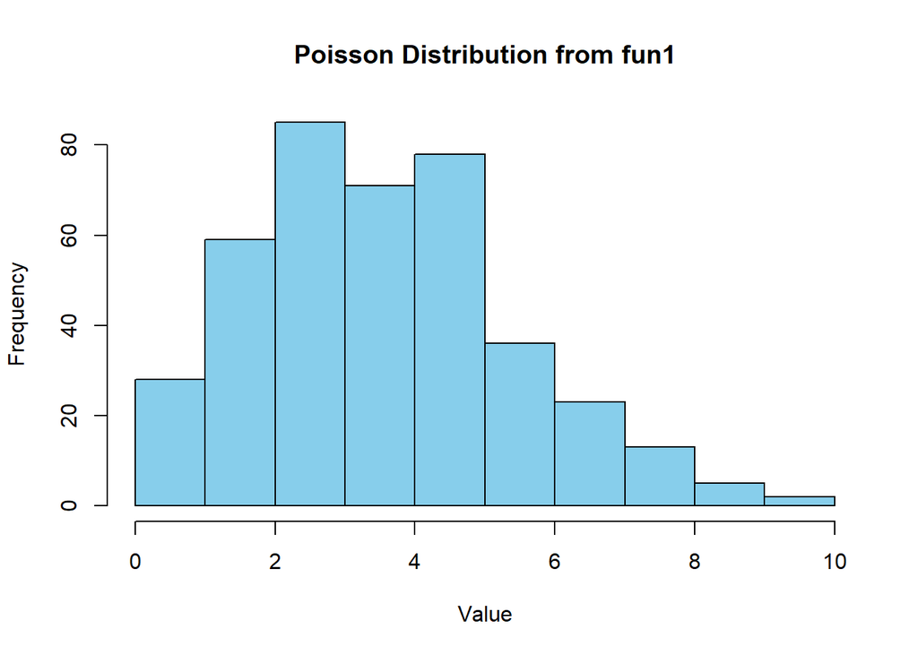

```r
fun1 <- function(n = 100, k = 4, lambda = 4) {
  x <- NULL

  for (i in 1:n){
    x <- rbind(x, rpois(k, lambda))
  }

  return(x)
}

fun1alt <- function(n = 100, k = 4, lambda = 4) {
  matrix(rpois(n * k, lambda), nrow = n, ncol = k)
}

x1 = fun1()
x2 = fun1alt()

hist(as.vector(x1), main = "Poisson Distribution from fun1",
     xlab = "Value", col = "skyblue")
```

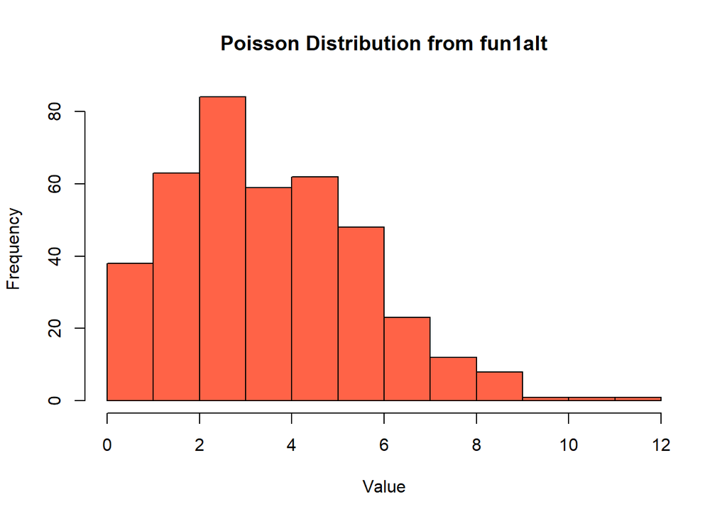

```r
hist(as.vector(x2), main = "Poisson Distribution from fun1alt", xlab = "Value", col = "tomato")
```

```r
microbenchmark(fun1(), fun1alt())
```

```
Unit: microseconds
      expr     min       lq      mean   median      uq      max neval
    fun1() 137.501 151.3505 187.47992 162.8005 179.551  507.801   100
 fun1alt()   9.401  10.1010  23.93201  10.5510  11.901 1200.601   100
```

### Part 2: Max of Each Column

```r
# Data Generating Process (10 x 10,000 matrix)
set.seed(1234)
x <- matrix(rnorm(1e4), nrow=10)

# Find each column's max value
fun2 <- function(x) {
  apply(x, 2, max)
}

fun2alt = function(x) {
  y = ncol(x)
  out = numeric(y)

  for (k in 1:y) {
    out[k] <- max(x[, k])
  }
  out
}

microbenchmark(fun2(x), fun2alt(x))
```

```
Unit: microseconds
       expr   min       lq    mean   median       uq      max neval
    fun2(x) 536.9 565.7005 661.698 596.7515 673.0505 2196.101   100
 fun2alt(x) 312.0 334.7510 410.581 354.9510 384.4505 2662.400   100
```

```r
x11 = fun2(x)
x22 = fun2alt(x)

sum(x11-x22) #Sums to zero, all entries are the same
```

```
[1] 0
```

## Problem 2: Parallelization

```r
library(parallel)


my_boot <- function(dat, stat, R, ncpus = 2L) {
  cl <- makeCluster(ncpus)

  n <- nrow(dat)
  idx <- matrix(sample.int(n, n*R, TRUE), nrow=n, ncol=R)

  clusterExport(cl, c("dat", "idx", "stat"), envir = environment())

  ans <- parLapply(cl, seq_len(R), function(i) {
    stat(dat[idx[,i], , drop=FALSE])
  })

  # Converting the list into a matrix
  ans <- do.call(rbind, ans)

  return(ans)
}

# Bootstrap of an OLS
my_stat <- function(d) coef(lm(y ~ x, data=d))

# DATA SIM
set.seed(1)
n <- 500; R <- 1e4

x <- cbind(rnorm(n)); y <- x*5 + rnorm(n)

# Checking if we get something similar as lm
ans0 <- confint(lm(y~x))
ans1 <- my_boot(dat = data.frame(x, y), my_stat, R = R, ncpus = 2L)

# You should get something like this
t(apply(ans1, 2, quantile, c(.025,.975)))
```

```
                  2.5%      97.5%
(Intercept) -0.1386903 0.04856752
x            4.8685162 5.04351239
```

```r
##                   2.5%      97.5%
## (Intercept) -0.1372435 0.05074397
## x            4.8680977 5.04539763
ans0
```

```
                 2.5 %     97.5 %
(Intercept) -0.1379033 0.04797344
x            4.8650100 5.04883353
```

```r
##                  2.5 %     97.5 %
## (Intercept) -0.1379033 0.04797344
## x            4.8650100 5.04883353
```

I did in fact get an answer very similar to the provided output, showing that the two are approximately the same.

```r
system.time({my_boot(dat = data.frame(x, y), my_stat, R = R, ncpus = 2L)})
```

```
   user  system elapsed
   0.19    0.03    2.99
```

```r
system.time({my_boot(dat = data.frame(x, y), my_stat, R = R, ncpus = 1L)})
```

```
   user  system elapsed
   0.20    0.01    3.95
```

## Problem 3: Short Answer

1. How you can decide if a problem is fit for parallelization?

You can tell if a problem is fit for parallelization if it has many steps that can be completed without the output of another. For example, finding the max value of 1000 different dataframes are independent tasks that could be sped up through parallelization. Some task may require minor dependancies which can be addressed in the setup of the parallelization. These are still excellent candidates for parallelization. Tasks that are fully dependent on the task before cannot be parallelized.

2. How you can think about the relationship between vectorization and parallelization? How do we know whether we should use one or the other or both?

Vectorization and parallelization are both methods used to speed up internal processes in computing. Vectorization is a way of running multiple processes at once, but only on one core. Instead of waiting on dependent processes (such as for loops), vectorization helps optimize the amount of wait time a computer needs to do. Parallelization is a method used to distribute multiple (hopefully unrelated) tasks onto multiple cores, which speeds up the process. All vectorization problems can be parallelized, but not all parallelization problems can be vectorized. To determine which to use (or both), one needs to look at the dependancy of the tasks, as well as the ability for the process to happen relatively simulataneously as opposed to linearly.